# Introdução_Python

## **Criando Lógica de Programação com Python**

O Python consegue realizar operações matemáticas. Contudo, as strings (nomes) sempre precisam estar entre aspas simples (utilização mais comum) ou aspas compostas.

```python
"Guilherme"
```

```
'Guilherme'
```

```python
'Guilherme'
```

```
'Guilherme'
```

```python
1+1
```

```
2
```

## **Criando Variáveis**

```python
Idade = 28
Idade
```

```
28
```

```python
Idade + 3
```

```
31
```

```python
Idade
```

```
28
```

```python
Idade = Idade + 3
Idade
```

```
31
```

```python
nome = 'Guilherme'
nome
```

```
'Guilherme'
```

```python
nome = 'Guilherme'
print(nome)
```

```
Guilherme
```

**Print** é a função utlizada em Paython para exibir na tela resultados/ Conteúdos. Para executar uma função, eu a coloco entre ().

```python
print(f'o nome é {nome} e a sua idade é {Idade} anos')
```

[output not shown]

## **Criando minha Primeira Função**

Na linha 23 criamos a função 'saudacao' e na linha 24 executamos a função 'saudacao'

```python
def nome_completo():
  primeiro_nome = input('qual seu primeiro nome? ')
  sobrenome = input('qual o seu sobrenome? ')
  nome_inteiro = primeiro_nome + ' ' + sobrenome
  print(nome_inteiro)
```

```python
nome_completo()
```

```
qual seu primeiro nome? Igor
qual o seu sobrenome? Pereira
Igor Pereira
```

```python
def saudacao():
  nome = input('Qual o seu nome? ')
  print(f'olá {nome}')
```

```python
saudacao()
```

```
Qual o seu nome? Igor
olá Igor
```

```python
def mais_um_ano(Idade):
  print('ta dentro dessa funcao')
  return Idade + 1
```

```python
mais_um_ano(43)
```

```
ta dentro dessa funcao
```

```
44
```

Eu tenho uma lista com vários filmes. Então, não faz sentido criar uma variável para cada filme como no exemplo abaixo:

```python
filme1 ='Toy Story 17'
filme2 = 'A Xuxa contra o Baixo Astral'
filme3 = 'Matrix 1'
```

```python
filmes = [filme1, filme2, filme3]
filmes
```

```
['Toy Story 17', 'A Xuxa contra o Baixo Astral', 'Matrix 1']
```

Para faciliar a organização das variáveis, eu crio uma única variável chamada 'filmes' e entre [] eu crio uma lista de filmes que farão parte da minha variável 'filmes'. Vide Exemplo abaixo:

```python
filmes = ['Toy Story 17','A Xuxa Contra o Baixo Astral', 'Matrix 1']
filmes
```

```
['Toy Story 17', 'A Xuxa Contra o Baixo Astral', 'Matrix 1']
```

```python
def imprime_filmes(filmes_que_quero_imprimir):
  print('A Lista de filmes que eu tenho disponível')
  print(filmes_que_quero_imprimir)
```

```python
imprime_filmes(filmes)
```

```
A Lista de filmes que eu tenho disponível
['Toy Story 17', 'A Xuxa contra o Baixo Astral', 'Matrix 1']
```

Para visualizar '**A Lista de Filmes que tenho disponível**' por posição, é preciso digitar o nome da váriável **'filmes'e entre [] a posição (número)** do filme da minha lista que eu quero visualizar. Lembrando que em programação [0] = primeiro da lista, [1] = segundo da lista e por aí em diante. [-1] = último da lista, [-2] = penúltimo da lista, [-3] = antepenúltimo da lista. Logo abaixo, segue um exemplo:

```python
filmes[0]
```

```
'Toy Story 17'
```

```python
filmes[1]
```

```
'A Xuxa contra o Baixo Astral'
```

```python
filmes[2]
```

```
'Matrix 1'
```

```python
filmes[-1]
```

```
'Matrix 1'
```

```python
filmes[-2]
```

```
'A Xuxa contra o Baixo Astral'
```

```python
filmes[-3]
```

```
'Toy Story 17'
```

Para visualizar os dados de uma lista de uma determinada posião em diante é só acrescentar os ':' após a posição da váriável que está entre [ ]. **Slicing** and **Dicing** (é o nome dados para esses recortes. Segue exemplo:

```python
filmes[1:]
```

```
['A Xuxa contra o Baixo Astral', 'Matrix 1']
```

```python
filmes[2:]
```

```
['Matrix 1']
```

Para visualizar todos os filmes da minha lista de filme um a um por linha, podemos criar a seguinte função.

```python
for filme in filmes:
  print(filme)
```

```
Toy Story 17
A Xuxa contra o Baixo Astral
Matrix 1
```

```python
for filme in filmes:
  print(filme)
  print('...')
```

```
Toy Story 17
...
A Xuxa contra o Baixo Astral
...
Matrix 1
...
```

```python
def imprime_filmes(filmes_que_quero_imprimir):
  print('A Lista de filmes que eu tenho disponível')
  for filme in filmes_que_quero_imprimir:
    print(filme)
```

```python
imprime_filmes(filmes)
```

```
A Lista de filmes que eu tenho disponível
Toy Story 17
A Xuxa contra o Baixo Astral
Matrix 1
```

## **Criando Dicionário**

```python
dados = {'nome': 'Guilherme',
         'idade': 37,
         'empresa': 'Alura'}
```

```python
dados
```

```
{'nome': 'Guilherme', 'idade': 37, 'empresa': 'Alura'}
```

```python
dados ['empresa']
```

```
'Alura'
```

## **Função com Parâmetro**

```python
nome = 'Junia'
```

```python
def saudacao_com_parametros(nome_da_pessoa):
  print(f'olá {nome_da_pessoa}')
```

```python
saudacao_com_parametros(nome)
```

```
olá Junia
```

## **Função Condicional**

```python
idade = 20
```

```python
def verifica_se_pode_dirigir():
  if idade >= 18:
    print('tem permissão para dirigir')
  else:
    print('não tem permissão para dirigir')
```

```python
verifica_se_pode_dirigir()
```

```
tem permissão para dirigir
```

## **Convertendo Tipo de Dados: string para inteiro**

Vamos criar esta mesma função, porém sem parâmetros desta vez. Lembrando que vamos converter o tipo de dado de string para inteiro. Vide exemplo abaixo:

```python
def verifica_se_pode_dirigir_sem_parametros():
  idade = input('qual sua idade? ')
  idade = int(idade)
  if idade >= 18:
    print('tem permissão para dirigir')
  else:
    print('não tem permissão para dirigir')
```

```python
verifica_se_pode_dirigir_sem_parametros()
```

```
qual sua idade? 17
não tem permissão para dirigir
```

Exercício de fixação de conteúdo:

Uma pessoa vai até a padaria todos os dias. A distância de sua casa até o estabelecimento é de 100 metros e todo percurso é feito em 20 segundos.

Para calcular a velocidade média e descobrir a razão do espaço pelo tempo, podemos dividir o espaço percorrido pelo tempo.

Sabendo disso, a pessoa deseja criar uma função chamada velocidade, que recebe 2 parâmetros chamados espaco e tempo, realizar o cálculo e exibir uma saída semelhante ao exemplo abaixo:

```python
def velocidade(espaço, tempo):
  v = espaço / tempo
  print(f'velocidade: {v}m/s')
```

```python
velocidade(100, 20)
```

```
velocidade: 5.0m/s
```

**Habilitação e TypeError**

Solução: idade = input('qual a sua idade? ') idade = int(idade)

```python
def habilitacao():
  idade = input('qual a sua idade? ')
  idade = int(idade)
  if idade >= 18:
    print('pode tirar a habilitação')
  else:
    tempo = 18 - idade
    print(f'Calma... Espere {tempo} anos(s) para tirar habilitação')

habilitacao()
```

```
qual a sua idade? 17
Calma... Espere 1 anos(s) para tirar habilitação
```

## **Criando Lista**

```python
idade = 22
idade
```

```
22
```

```python
type(idade)
```

```
int
```

```python
nome = 'Guilherme'
type(nome)
```

```
str
```

```python
idades = [18, 22, 15, 50 ]
type(idades)
```

```
list
```

```python
idades[2]
```

```
15
```

```python
idades = [18, 22, 15, 50 ]
#         0    1   2   3
#         0   -3  -2  -1
```

```python
idades[1]
```

```
22
```

```python
idades[2]
```

```
15
```

```python
idades [0:2]
```

```
[18, 22]
```

```python
idades[1:]
```

```
[22, 15, 50]
```

```python
idades[-1]
```

```
50
```

```python
idades[-2]
```

```
15
```

## **Laços e Loops**

```python
idades
```

```
[18, 22, 15, 50]
```

```python
# 'for' está fora da função
def verifica_se_pode_dirigir(idade):
  if idade>= 18:
    print(f'{idade} anos de idade, Tem permissão para dirigir' )
  else:
    print(f'{idade} anos de idade, Não tem permissão para dirigir' )
for idade in idades:
  verifica_se_pode_dirigir(idade)
```

```
18 anos de idade, Tem permissão para dirigir
22 anos de idade, Tem permissão para dirigir
15 anos de idade, Não tem permissão para dirigir
50 anos de idade, Tem permissão para dirigir
```

```python
# 'for dentro da função
def verifica_se_pode_dirigir(idades):
  for idade in idades:
    if idade>= 18:
      print(f'{idade} anos de idades, Tem permissão para dirigir' )
    else:
      print(f'{idade} anos de idade, Não tem permissão para dirigir' )

verifica_se_pode_dirigir(idades)
```

```
18 anos de idades, Tem permissão para dirigir
22 anos de idades, Tem permissão para dirigir
15 anos de idade, Não tem permissão para dirigir
50 anos de idades, Tem permissão para dirigir
```

## **Booleano**

```python
idade = 18
idade >= 18
```

```
True
```

```python
idade = 15
idade >= 18
```

```
False
```

```python
# criando as listas permissoes e idades
permissoes = []
idades = [20, 14, 40]

def verifica_se_pode_dirigir(idades, permissoes):
  for idade in idades:
    if idade >= 18:
      permissoes.append(True)
    else:
      permissoes.append(False)

verifica_se_pode_dirigir(idades, permissoes)
```

```python
permissoes
```

```
[True, False, True]
```

```python
idades
```

```
[20, 14, 40]
```

```python
for permissao in permissoes:
  if permissao ==True:
    print('Tem permissão para dirigir' )
  else:
    print('Não ten permissao para dirigir' )
```

```
Tem permissão para dirigir
Não ten permissao para dirigir
Tem permissão para dirigir
```

**Exercício de Fixação:**

A plataforma da Alura possui diversos cursos de tecnologia e negócios. Podemos afirmar que a plataforma possui:

**Cursos de Tecnologia e Negócios Digitais**

observe o código abaixo com todas as palavras em uma lista fora de ordem:

Então, para exibir o slogan de forma correta usaremos o código abaixo:

frase_alura[-1] + frase_alura[3] + frase_alura[-2] + frase_alura[1] + frase_alura[2] + frase_alura[0]

```python
frase_alura = [' Digitais', 'e ', 'Negócios ', 'de ', 'Tecnologia ', 'Cursos ']
frase_alura
```

```
[' Digitais', 'e ', 'Negócios ', 'de ', 'Tecnologia ', 'Cursos ']
```

```python
frase_alura[-1] + frase_alura[3] + frase_alura[-2] + frase_alura[1] + frase_alura[2] + frase_alura[0]
```

```
'Cursos de Tecnologia e Negócios  Digitais'
```

```python
a=2

if a < 2:
 a = a + 1
else:
 a = a + 2
if a < 4:
 a = a - 4
else:
 a = a + 6

a
```

```
10
```

## **Tipos de Dados em uma Lista**

```python
lista = ['Guilherme', 28, True, '18']

for elemento in lista:
  print(f'o elemento {elemento} é do tipo: ', type(elemento))
```

```
o elemento Guilherme é do tipo:  <class 'str'>
o elemento 28 é do tipo:  <class 'int'>
o elemento True é do tipo:  <class 'bool'>
o elemento 18 é do tipo:  <class 'str'>
```

## **Import Randrange e Seed**

```python
from random import randrange, seed
```

```python
seed(11)
```

```python
randrange(0,11)
```

```
7
```

```python
notas_matematica = []

for notas in range(8):
  notas_matematica.append(randrange(0,11))
```

```python
notas_matematica
```

```
[8, 7, 7, 8, 9, 3, 2, 8]
```

```python
len(notas_matematica)
```

```
8
```

## **Matplotlib**

```python
import matplotlib.pyplot as plt
```

```python
x = list(range(1,9))
x
```

```
[1, 2, 3, 4, 5, 6, 7, 8]
```

```python
y = notas_matematica
y
```

```
[8, 7, 7, 8, 9, 3, 2, 8]
```

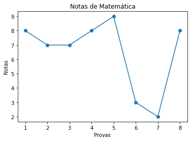

```python
plt.plot(x,y, marker='o')
plt.title('Notas de Matemática')
plt.xlabel('Provas')
plt.ylabel('Notas')
plt.show()
```

```python
notas_matematica
```

```
[8, 7, 7, 8, 9, 3, 2, 8]
```

```python
# Uma lista é representada como uma sequência de objetos separados por vírgula e dentro de colchetes [].
# No Python, uma lista pode armazenar elementos de diferentes tipos, como ilustra o código abaixo:

lista = ['int', False, True, '18', 2020]

# Para descobrir o tipo de cada elemento, podemos criar um loop, como mostra o código abaixo:

for elemento in lista:
 print(type(elemento))
```

```
<class 'str'>
<class 'bool'>
<class 'bool'>
<class 'str'>
<class 'int'>
```

```python
import matplotlib.pyplot as plt

notas_matematica = ['Matemática',8,7,6,6,7,7,8,10]
notas_portugues = ['Português',9,9,9,8,5,6,8,5]
notas_geografia = ['Geografia',10,10,6,7,7,7,8,7]

notas = [notas_matematica, notas_portugues, notas_geografia]
```

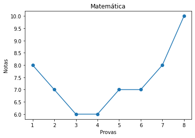

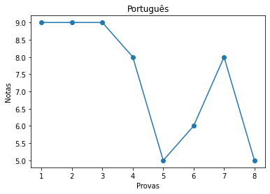

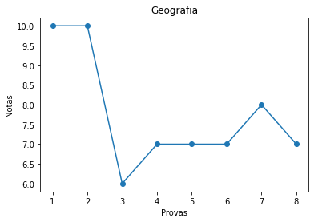

```python
for nota in notas:
 x = list(range(1, 9))
 y = nota[1:]
 plt.plot(x, y, marker='o')
 plt.xlabel('Provas')
 plt.ylabel('Notas')
 plt.title(nota[0])
 plt.show()
```